# STAC33 A1

Khusanbek Mukhammad Azim

28/01/2021

```r
library(tidyverse)
```

## Question 1

## (a)

```r
my_url <- "http://ritsokiguess.site/STAC32/rainfall.txt"
rainfall <- read_delim(my_url, " ")
rainfall
```

```
## # A tibble: 47 x 2
##     Year Rainfall
##    <dbl>    <dbl>
##  1  1951     20.7
##  2  1952     16.7
##  3  1953     13.5
##  4  1954     14.1
##  5  1955     25.4
##  6  1956     12.0
##  7  1957     28.7
##  8  1958     11.0
##  9  1959     12.6
## 10  1960     12.8
## # ... with 37 more rows
```

## (b)

Since we are comparing 2 quantitative variables, scatterplot would be appropriate.

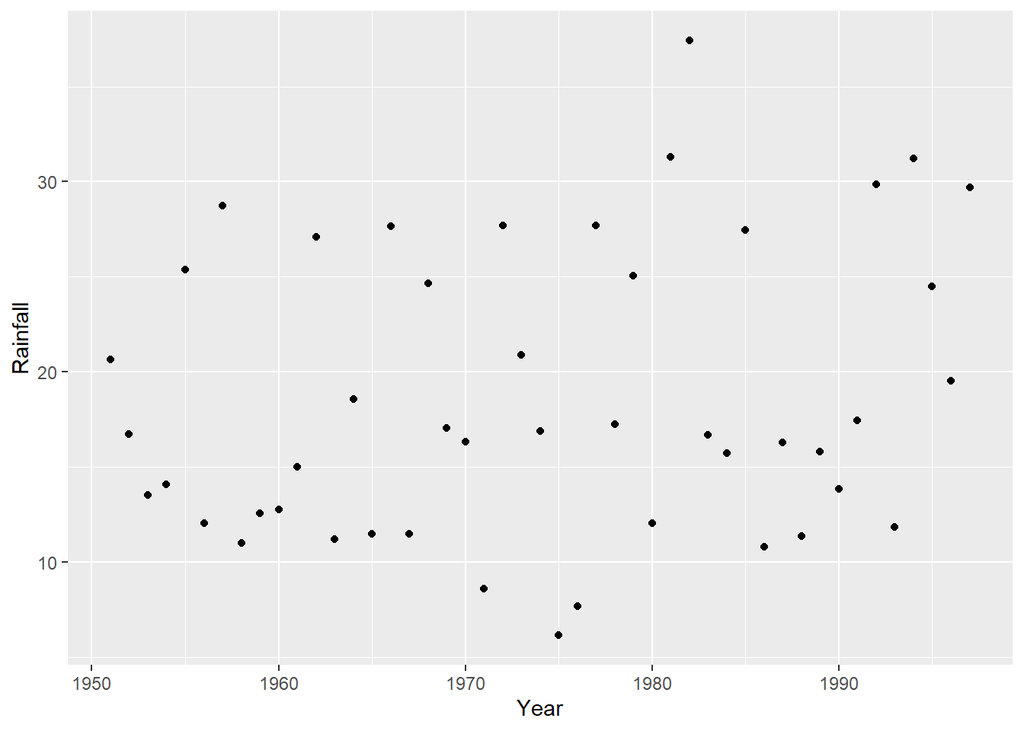

```r
ggplot(rainfall, aes(x=Year, y=Rainfall)) + geom_point()
```

Placing year as the explanatory variable and rainfall as the response variable since we are interested in how the rainfall changes over time.

Setting Rainfall as the explanatory variable would not make sense since that would mean analyzing how years are explained by rainfall.

## (c)

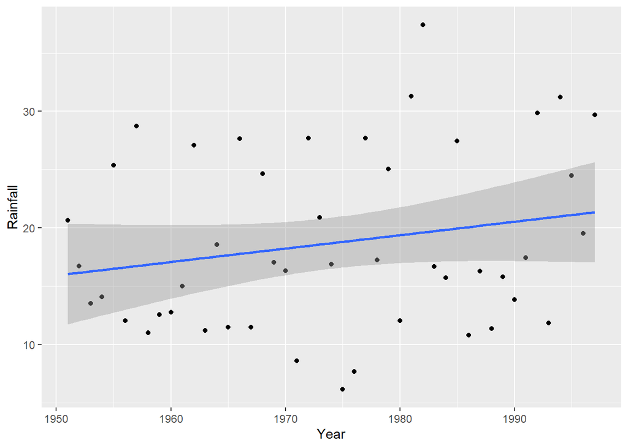

```r
ggplot(rainfall, aes(x=Year, y=Rainfall)) + geom_point() + geom_smooth(method = "lm")
```

From the regression line we can see that there is a weak positive linear relationship between the year and rainfall. This implies that the annual rainfall for Davis, California is slowly increasing over time.

## 2

## (a)

```r
my_url <- "http://ritsokiguess.site/STAC33/algebra.txt"
grades <- read_table(my_url)
grades
```

```
## # A tibble: 47 x 2
##    laptop score
##    <chr>  <dbl>
##  1 yes       98
##  2 yes       84
##  3 yes       97
##  4 yes       93
##  5 yes       88
##  6 yes       57
##  7 yes      100
##  8 yes       84
##  9 yes      100
## 10 yes       81
## # ... with 37 more rows
```

We have 20+27=47, which is the number of rows. The first column, laptop, is either yes or no. The second column, score, is quantitative as expected. In total we have 47 rows and 2 columns.

## (b)

Our data is made up of one categorical and one quantitative, therefore side-by-side boxplots would be appropriate.

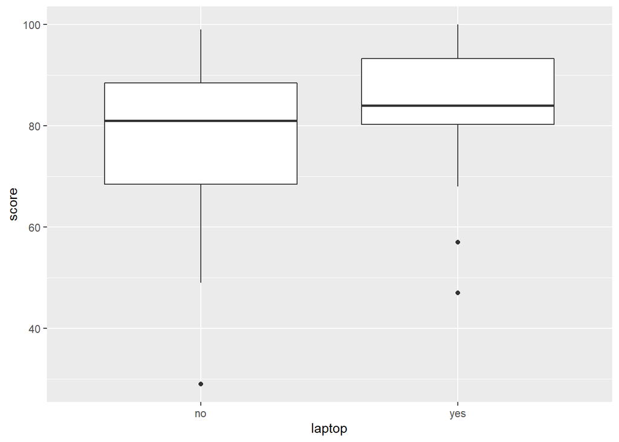

```r
ggplot(grades, aes(x=laptop, y=score)) + geom_boxplot()
```

## (C)

The median grades for students with and without a laptop are similar, but students with no laptop had grades that ranged from 50%-100% whereas students with a laptop had grades that ranged from 68%-100%. Students with laptops overall had better grades than students without laptops.

## (d)

```r
grades %>%
  group_by(laptop) %>%
  summarize(Median=median(score), IQR=IQR(score))
```

```
## # A tibble: 2 x 3
##   laptop Median   IQR
## * <chr>   <dbl> <dbl>
## 1 no         81    20
## 2 yes        84    13
```

Boxplot for reference

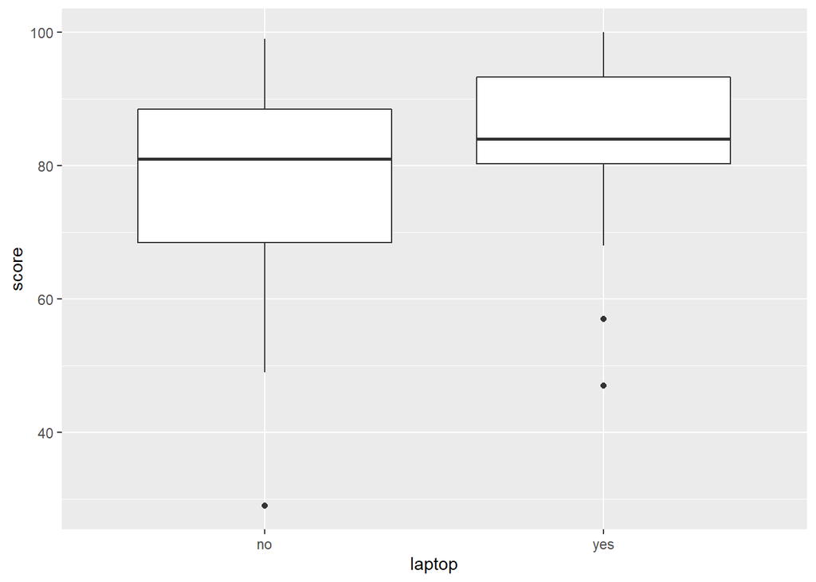

```r
ggplot(grades, aes(x=laptop, y=score)) + geom_boxplot()
```

The median score for students without laptops of 81 is similar but lower than the score of 84 for students with laptops. This is supported by the median line in the boxplot being higher for students with laptops.

The IQR for students without laptops of 20 is higher than students with laptops IQR of 13. This can also be seen in the larger box for students with no laptops and a smaller box for students with a laptop.